# Datasets

##### Vertebral column 2

#### 10 or more attributes

##### Travel insurance

A third-party travel insurance servicing company that is based in Singapore.

- **Source**: [Kaggle](https://www.kaggle.com/mhdzahier/travel-insurance#travel%20insurance.csv)
- **Number of rows**: 18219
- **Number of attributes**: 10

**Description of the attributes:**

- Target: Claim Status (Claim.Status)
- Name of agency (Agency)
- Type of travel insurance agencies (Agency.Type)
- Distribution channel of travel insurance agencies (Distribution.Channel)
- Name of the travel insurance products (Product.Name)
- Duration of travel (Duration)
- Destination of travel (Destination)
- Amount of sales of travel insurance policies (Net.Sales)
- Commission received for travel insurance agency (Commission)
- Gender of insured (Gender)
- Age of insured (Age)

[figure not shown]

```r
plot_dist_cols(travel_insurance)
```

### Numeric attributes

#### Less than 10 attributes

##### Banknote authentication

- **Source**: [UCI Machile Learning Repository](http://archive.ics.uci.edu/ml/datasets/banknote+authentication)
- **Number of rows**: 1372
- **Number of attributes**: 4

Data were extracted from images that were taken from genuine and forged banknote-like specimens. For digitization, an industrial camera usually used for print inspection was used. The final images have 400x 400 pixels. Due to the object lens and distance to the investigated object gray-scale pictures with a resolution of about 660 dpi were gained. Wavelet Transform tool were used to extract features from images.

**Description of the attributes:**

- variance of Wavelet Transformed image (continuous)
- skewness of Wavelet Transformed image (continuous)
- curtosis of Wavelet Transformed image (continuous)
- entropy of image (continuous)
- class

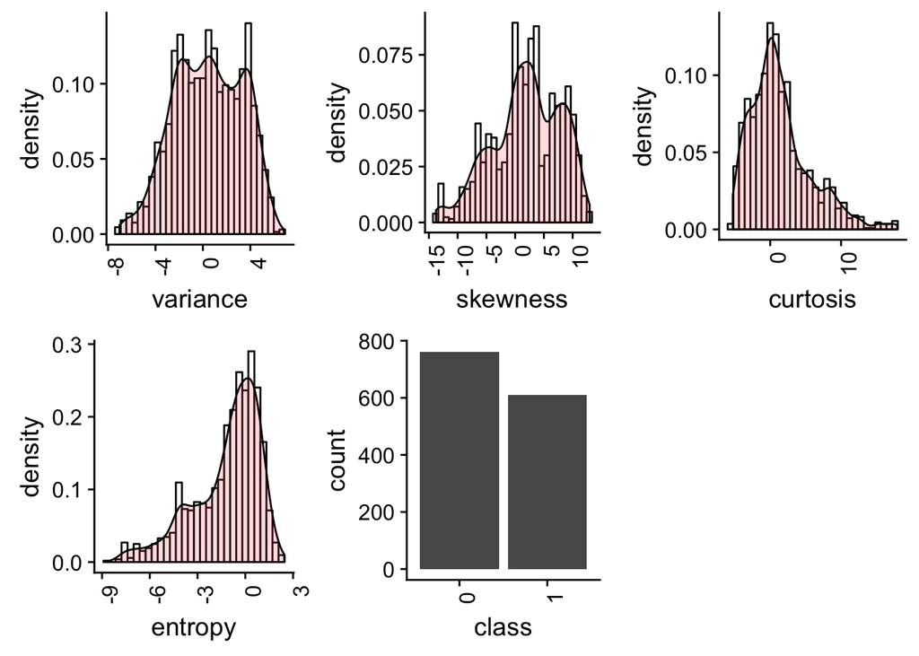

```r
plot_dist_cols(bank_note)
```

##### Haberman

- **Source**: [UCI Machile Learning Repository](http://archive.ics.uci.edu/ml/datasets/Haberman%27s+Survival)
- **Number of rows**: 306
- **Number of attributes**: 3

The dataset contains cases from a study that was conducted between 1958 and 1970 at the University of Chicago’s Billings Hospital on the survival of patients who had undergone surgery for breast cancer.

- Age of patient at time of operation (numerical)
- Patient’s year of operation (year - 1900, numerical)
- Number of positive axillary nodes detected (numerical)
- Survival status (class attribute)
  - 1 = the patient survived 5 years or longer
  - 2 = the patient died within 5 year

**Description of the attributes:**

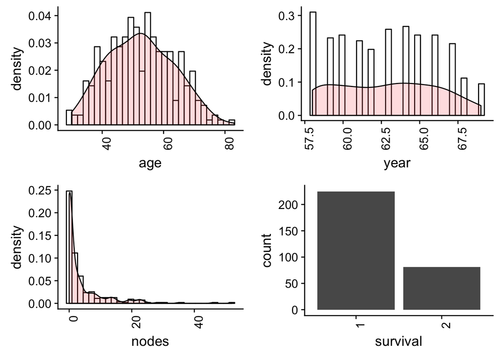

```r
plot_dist_cols(haberman)
```

##### Skin segmentation

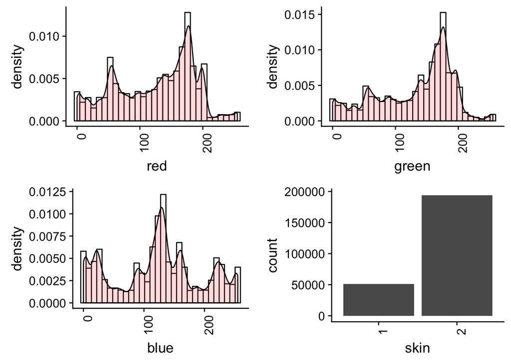

```r
plot_dist_cols(skin)
```

#### 10 or more attributes

## Multiclass

### Categorical attributes

#### Less than 10 attributes

##### Balance Scale

This data set was generated to model psychological experimental results. Each example is classified as having the balance scale tip to the right, tip to the left, or be balanced. The attributes are the left weight, the left distance, the right weight, and the right distance. The correct way to find the class is the greater of $(left\_distance * left\_weight)$ and $(right\_distance * right\_weight)$. If they are equal, it is balanced.

- **Source**: [UCI Machile Learning Repository](http://archive.ics.uci.edu/ml/datasets/Balance+Scale)
- **Number of rows**: 625
- **Number of attributes**: 4

**Description of the attributes:**

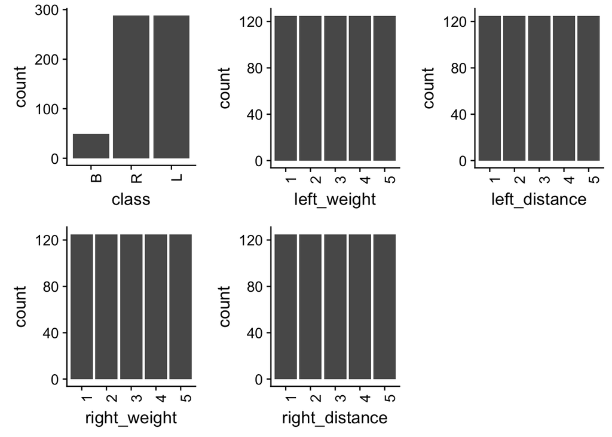

##### Chess

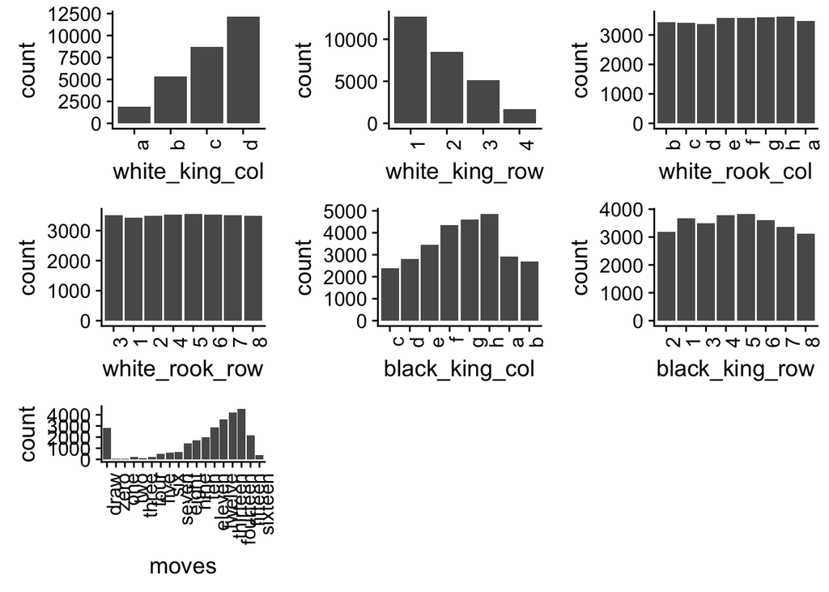

```r
plot_dist_cols(chess)
```